# nlp_strategy by Luis Felipe Villota

#### 4.1 First visualizations: tf distribution and Zipf´s Law

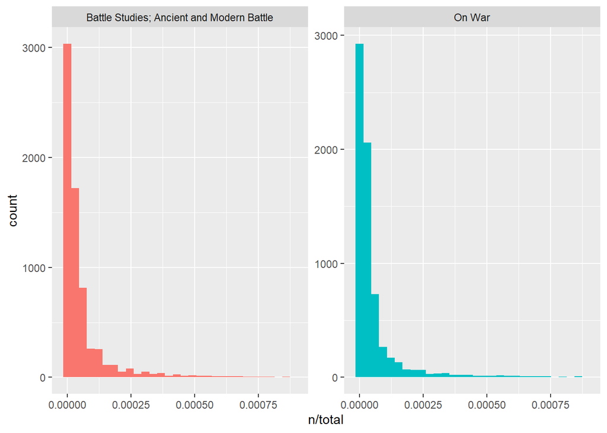

```r
# Term frequency distribution: ocurrences of a word (in each of our books) divided by the total amount of words (of the respective work) (Ibid.; 3.1).

ggplot(l_b_1, aes(n/total, fill = title)) +
  geom_histogram(show.legend = FALSE) +
  xlim(NA, 0.0009) +
  facet_wrap(~title, ncol = 2, scales = "free_y")
```

```r
# We are actually interested in the long tails to help us see the amount of rare words in each of the works (those which make a book distinguishable).

# This is observed as the Zipf's law: which establishes that the occurrence of a word is inversely proportional to its rank (Ibid.; 3.2).

# Example as seen in (Ibid.)

f_by_rank <- l_b_1 %>%
  group_by(title, author) %>%
  mutate(rank = row_number(),
         `term frequency` = n/total) %>%
  ungroup()

f_by_rank
```

```
## # A tibble: 13,854 × 8
##    gutenberg_id title           author word      n  total  rank `term frequency`
##           <int> <chr>           <chr>  <chr> <int>  <int> <int>            <dbl>
##  1         1946 On War          Claus… the    8439 107826     1           0.0783
##  2         7294 Battle Studies… Ardan… the    6611  81468     1           0.0811
##  3         1946 On War          Claus… of     5295 107826     2           0.0491
##  4         7294 Battle Studies… Ardan… of     3289  81468     2           0.0404
##  5         1946 On War          Claus… in     3046 107826     3           0.0282
##  6         1946 On War          Claus… to     2969 107826     4           0.0275
##  7         1946 On War          Claus… and    2673 107826     5           0.0248
##  8         1946 On War          Claus… a      2491 107826     6           0.0231
##  9         7294 Battle Studies… Ardan… to     2249  81468     3           0.0276
## 10         1946 On War          Claus… is     2198 107826     7           0.0204
## # ℹ 13,844 more rows
```

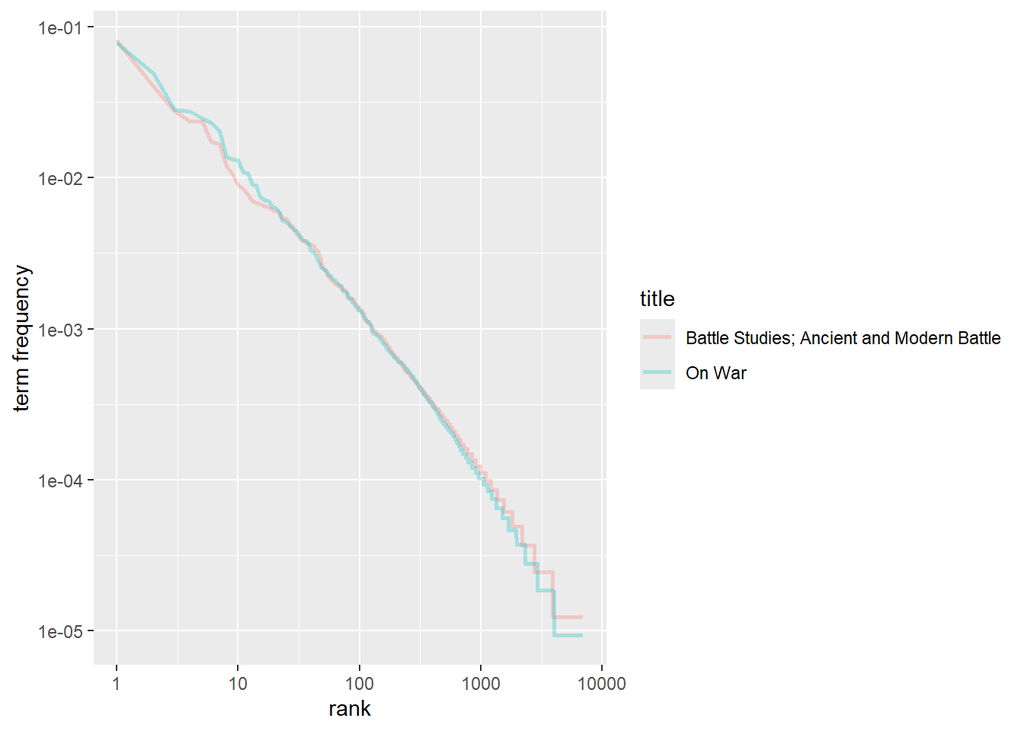

```r
f_by_rank %>%
  ggplot(aes(rank, `term frequency`, color = title)) +
  geom_line(size = 0.9, alpha = 0.3, show.legend = TRUE) +
  scale_x_log10() +
  scale_y_log10()
```

#### 4.2 The tf-idf statistic

```r
# Gathering tf_idf by gutenberg_id, title and author with total words per title and author together (Ibid.; 3.3).

lib_tf_idf <- l_b_1 %>% bind_tf_idf(word, title, n)

lib_tf_idf
```

```
## # A tibble: 13,854 × 9
##    gutenberg_id title              author word      n  total     tf   idf tf_idf
##           <int> <chr>              <chr>  <chr> <int>  <int>  <dbl> <dbl>  <dbl>
##  1         1946 On War             Claus… the    8439 107826 0.0783     0      0
##  2         7294 Battle Studies; A… Ardan… the    6611  81468 0.0811     0      0
##  3         1946 On War             Claus… of     5295 107826 0.0491     0      0
##  4         7294 Battle Studies; A… Ardan… of     3289  81468 0.0404     0      0
##  5         1946 On War             Claus… in     3046 107826 0.0282     0      0
##  6         1946 On War             Claus… to     2969 107826 0.0275     0      0
##  7         1946 On War             Claus… and    2673 107826 0.0248     0      0
##  8         1946 On War             Claus… a      2491 107826 0.0231     0      0
##  9         7294 Battle Studies; A… Ardan… to     2249  81468 0.0276     0      0
## 10         1946 On War             Claus… is     2198 107826 0.0204     0      0
## # ℹ 13,844 more rows
```

```r
lib_tf_idf %>% arrange(desc(tf_idf))
```

```
## # A tibble: 13,854 × 9
##    gutenberg_id title            author word      n  total      tf   idf  tf_idf
##           <int> <chr>            <chr>  <chr> <int>  <int>   <dbl> <dbl>   <dbl>
##  1         7294 Battle Studies;… Ardan… mora…    78  81468 9.57e-4 0.693 6.64e-4
##  2         7294 Battle Studies;… Ardan… picq     68  81468 8.35e-4 0.693 5.79e-4
##  3         7294 Battle Studies;… Ardan… orga…    61  81468 7.49e-4 0.693 5.19e-4
##  4         7294 Battle Studies;… Ardan… arda…    54  81468 6.63e-4 0.693 4.59e-4
##  5         7294 Battle Studies;… Ardan… foot…    51  81468 6.26e-4 0.693 4.34e-4
##  6         1946 On War           Claus… obje…    65 107826 6.03e-4 0.693 4.18e-4
##  7         7294 Battle Studies;… Ardan… etc      46  81468 5.65e-4 0.693 3.91e-4
##  8         7294 Battle Studies;… Ardan… caes…    44  81468 5.40e-4 0.693 3.74e-4
##  9         7294 Battle Studies;… Ardan… rifle    44  81468 5.40e-4 0.693 3.74e-4
## 10         1946 On War           Claus… buon…    58 107826 5.38e-4 0.693 3.73e-4
## # ℹ 13,844 more rows
```

```r
# We see some important words (nouns, verbs, adjectives, etc.) for each book yet we observe some terms that apparently do not carry much meaning (fig, footnote, etc.)
```

#### 4.3 Removing stopwords

```r
# First, we customize a list of stopwords and then apply the anti_join() function with "stop_words" {tidytext package} as an argument (to further remove 1,149 stop words from our library).

customstopwords <- tibble(word =   c("1", "2", "3", "4","eq", "co", "rc", "ac", "ak", "bn",
"fig", "figs", "file", "cg", "cb", "cm","ab", "_k", "_k_", "_x","fig", "footnote",
"http", "of", "_of", "_ab_", "0", "deg","sidenote", "_a_","_b_", "_c_", "_o_",
"_s_", "_e_", "lu", "thou", "thy", "thee", "hast", "_abcd_", "nay", "consider'd",
"call'd", "hath", "gallery.euroweb.hu", "_an", "dost", "sayest", "seest", "thyself",
"wilt", "cf", "m.t.h.s", "_an", "shew", "shewn", "allow'd", "_c",
"transcribers", "diagram", "_photo", "_mn_", "_g_", "_p_", "_v_",
"_ac_", "_f_", "_d_", "_ad_", "_ef_", "tho", "mention'd",
"turn'd", "shewing", "form'd", "design'd", "etc", "chapter"))

tidy_words <- final_lib %>% unnest_tokens(word, text) %>%
  count(gutenberg_id, author, title, word, sort = TRUE) %>% anti_join(stop_words)%>%
                anti_join(customstopwords)
```

#### 4.4 Second visualization: tf-idf by title (without stopwords)

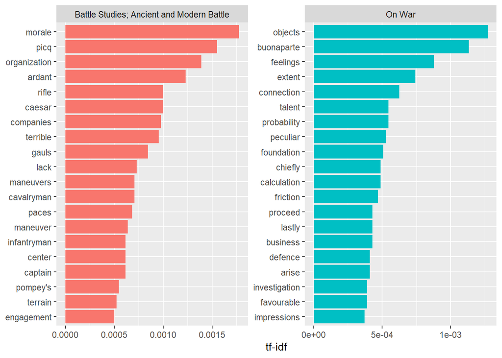

```r
# Visualizing tf_idf according to (Ibid.). Here the top 20 words (most ranked).

tidy_words_1 <- tidy_words  %>% bind_tf_idf(word, title, n)

tidy_words_1 %>%
  group_by(title) %>%
  slice_max(tf_idf, n = 20) %>%
  ungroup() %>%
  ggplot(aes(tf_idf, fct_reorder(word, tf_idf), fill = title)) +
  geom_col(show.legend = FALSE) +
  facet_wrap(~title, ncol = 4, scales = "free") +
  labs(x = "tf-idf", y = NULL)
```

#### 4.5 Wordcloud

```r
# Wordcloud2 tf_idf

w_cloud <- wordcloud2(tidy_words_1 %>% count(word, tf_idf, wt= tf_idf, sort = TRUE),
        minSize = 0, gridSize = 0, fontFamily = "mono",
        fontWeight = "normal", color = "random-light", backgroundColor = "grey",
        minRotation = -pi/4, maxRotation = pi/4, shuffle = TRUE, rotateRatio = 0.4,
        shape = "diamond", ellipticity = 0.65, widgetsize = NULL, figPath = NULL,
        hoverFunction = NULL
)

w_cloud + WCtheme(2) + WCtheme(3)
```

[interactive chart not shown]

### 5. **Relationships between words**

#### 5.1 Tokenizing by n-grams

```r
# Token= bigram. According to (Ibid.; 4.1)

strategy_bigrams <-final_lib %>% unnest_tokens(bigram, text, token = "ngrams", n= 2) %>% filter(!is.na(bigram))

strategy_bigrams # one token (a bigram) per row
```

```
## # A tibble: 172,298 × 4
##    gutenberg_id author               title  bigram
##           <int> <chr>                <chr>  <chr>
##  1         1946 Clausewitz, Carl von On War on war
##  2         1946 Clausewitz, Carl von On War by general
##  3         1946 Clausewitz, Carl von On War general carl
##  4         1946 Clausewitz, Carl von On War carl von
##  5         1946 Clausewitz, Carl von On War von clausewitz
##  6         1946 Clausewitz, Carl von On War on war
##  7         1946 Clausewitz, Carl von On War war general
##  8         1946 Clausewitz, Carl von On War general carl
##  9         1946 Clausewitz, Carl von On War carl von
## 10         1946 Clausewitz, Carl von On War von clausewitz
## # ℹ 172,288 more rows
```

#### 5.2 Counting initial bigrams, removing stop words and final count

```r
strategy_bigrams %>% count(bigram, sort= TRUE)
```

```
## # A tibble: 76,661 × 2
##    bigram      n
##    <chr>   <int>
##  1 of the   2227
##  2 in the   1124
##  3 to the    746
##  4 it is     699
##  5 on the    516
##  6 of a      401
##  7 to be     382
##  8 and the   360
##  9 at the    345
## 10 by the    334
## # ℹ 76,651 more rows
```

```r
# A significant amount of our tokens here include words without much meaning for our report such as "the", "of", "an", etc. Hence, we remove them (Ibid.; 4.1.1):

tidy_bigrams <-strategy_bigrams %>% separate(bigram,c("word1","word2"), sep = " ")

tidy_bigrams_1 <- tidy_bigrams %>% filter(!word1 %in% stop_words$word) %>% filter(!word2 %in% stop_words$word) %>% filter(!word1 %in% customstopwords) %>% filter(!word2 %in% customstopwords)

# New count after filtering the stopwords for the two words composing our token unit (Ibid.):

final_bigrams <- tidy_bigrams_1 %>%
  count(word1, word2, sort = TRUE)

final_bigrams # The bigram is separated in 2 columns.
```

```
## # A tibble: 11,419 × 3
##    word1     word2      n
##    <chr>     <chr>  <int>
##  1 du        picq      66
##  2 ardant    du        51
##  3 moral     effect    50
##  4 political object    26
##  5 colonel   ardant    24
##  6 enemy's   force     24
##  7 military  virtue    22
##  8 modern    battle    22
##  9 enemy's   army      21
## 10 moral     forces    21
## # ℹ 11,409 more rows
```

```r
# Gathering/unifying bigrams

final_bigrams_together <- final_bigrams %>% unite(bigram, word1,word2, sep = " ")

final_bigrams_together
```

```
## # A tibble: 11,419 × 2
##    bigram               n
##    <chr>            <int>
##  1 du picq             66
##  2 ardant du           51
##  3 moral effect        50
##  4 political object    26
##  5 colonel ardant      24
##  6 enemy's force       24
##  7 military virtue     22
##  8 modern battle       22
##  9 enemy's army        21
## 10 moral forces        21
## # ℹ 11,409 more rows
```

#### 5.3 Exploring bigrams: filtering for strategy

```r
# Example of filter to see the most common context of the word "strategy" (located at the end of a bigram) in each book.

tidy_bigrams_1 %>%
  filter(word2 == "strategy") %>%
  count(title, word1, sort = TRUE)
```

```
## # A tibble: 14 × 3
##    title                                     word1            n
##    <chr>                                     <chr>        <int>
##  1 On War                                    combat           2
##  2 On War                                    constituting     2
##  3 Battle Studies; Ancient and Modern Battle moltke's         1
##  4 On War                                    37               1
##  5 On War                                    book             1
##  6 On War                                    compose          1
##  7 On War                                    defeat           1
##  8 On War                                    effects          1
##  9 On War                                    forces           1
## 10 On War                                    keeping          1
## 11 On War                                    unfortunate      1
## 12 On War                                    victory          1
## 13 On War                                    war              1
## 14 On War                                    words            1
```

#### 5.5 Visualizing the network

```r
# Using the graph_from_data_frame function (Ibid.; 4.1.4)

final_bigrams_graph <- final_bigrams %>% filter(n > 10) %>% graph_from_data_frame()

final_bigrams_graph
```

```
## IGRAPH 18e6faa DN-- 39 28 --
## + attr: name (v/c), n (e/n)
## + edges from 18e6faa (vertex names):
##  [1] du        ->picq      ardant    ->du        moral     ->effect
##  [4] political ->object    colonel   ->ardant    enemy's   ->force
##  [7] military  ->virtue    modern    ->battle    enemy's   ->army
## [10] moral     ->forces    ancient   ->battle    ancient   ->combat
## [13] battle    ->field     hundred   ->meters    armed     ->force
## [16] military  ->force     military  ->history   military  ->spirit
## [19] reciprocal->action    fire      ->arms      historical->documents
## [22] positive  ->object    editor's  ->note      left      ->wing
## + ... omitted several edges
```

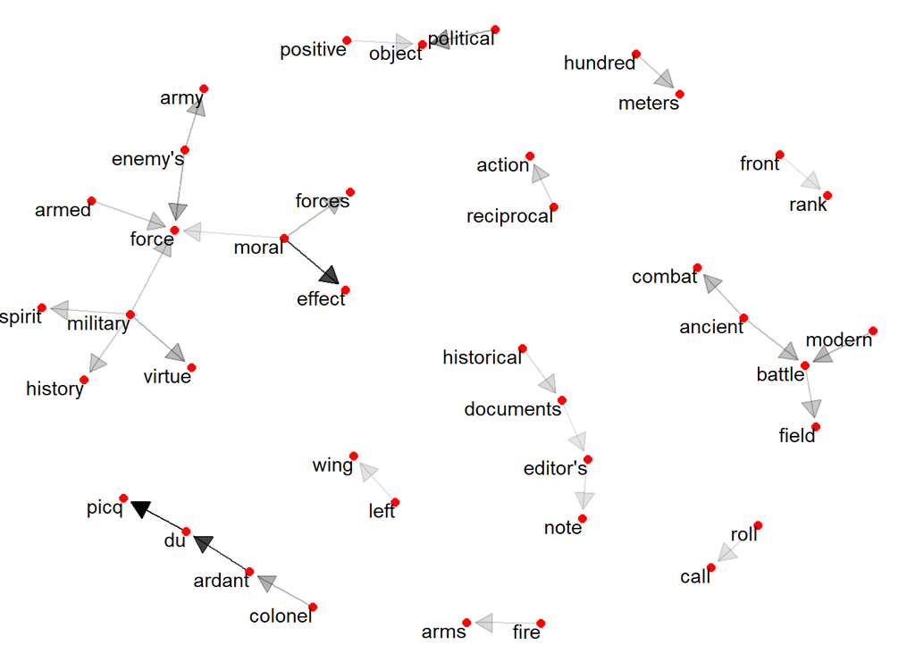

```r
set.seed(2023) # setting seed

arrow <- grid::arrow(type = "closed", length = unit(.15, "inches"))

# Using ggraph
library(ggraph)
ggraph(final_bigrams_graph, layout = "fr") +
  geom_edge_link(aes(edge_alpha = n), show.legend = FALSE,
                 arrow = arrow, end_cap = circle(.07, 'inches')) +
  geom_node_point(color = "red", size = 2) +
  geom_node_text(aes(label = name), vjust = 1, hjust = 1) +
  theme_void()
```

### References

Grimmer, J., & Stewart, B. M. (2013). Text as Data: The Promise and Pitfalls of Automatic Content Analysis Methods for Political Texts. *Political Analysis*, *21*(3), 267–297. https://doi.org/10.1093/pan/mps028

Kornberger, M., & Vaara, E. (2022). Strategy as engagement: What organization strategy can learn from military strategy. *Long Range Planning*, *55*(4), 102125. https://doi.org/10.1016/j.lrp.2021.102125

Neuendorf, K. A. (2017). *The Content Analysis Guidebook*. SAGE Publications, Inc. https://doi.org/10.4135/9781071802878

Sebastian, A. (2020, July 16). *A Gentle Introduction To Calculating The TF-IDF Values*. Medium. https://towardsdatascience.com/a-gentle-introduction-to-calculating-the-tf-idf-values-9e391f8a13e5

Silge, J., & Robinson, D. (2017). *Text Mining with R: A Tidy Approach* (1st edition). O’Reilly Media. https://www.tidytextmining.com/index.html